# Estudio de Caso Integrador · Pautas y Seguimiento

TD + FD + PD sobre una comunidad real del Caribe colombiano — Unidad V (semanas 14–17)

Autor/a

Diversidad Multidimensional de Comunidades Biológicas en R · OPT_0086

Fecha de publicación

22 de septiembre de 2026

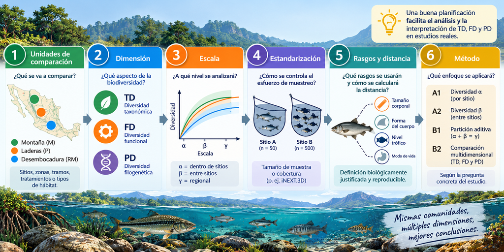

## Antes de empezar

**NotaQué es este documento**

Este es el **procedimiento paso a paso** de las pautas del estudio de caso integrador. Se irá completando semana a seman (enlaces, fechas exactas, integrantes de grupos, rúbrica final) a medida que esa información quede definida. Mientras tanto, cada sección marcada como **🔲 INSUMO PENDIENTE** indica dónde falta reemplazar un marcador por el dato real.

- **Resultado de aprendizaje protagonista:** RA3 — sustentar oral y por escrito un estudio de caso integrador de diversidad multidimensional sobre una comunidad real del Caribe colombiano. RA1 y RA2 también se evalúan aquí, porque el documento final exige calcular métricas correctas (RA1) dentro de un flujo reproducible en R (RA2).
- **Peso en la nota final:** 300 / 500 puntos (**60%**), según la sección 8 del microdiseño — la actividad de mayor peso individual del curso.
- **Docentes a cargo:** Javier Rodríguez Barrios y Cesar Tamaris Turizo, de forma conjunta.

Esta actividad se complementa con otras actividades prácticas:

- El [Taller 1](https://javier-2712.github.io/Manuales/9.Manual_d_multidim_26/html/Taller1_bases_datos_diversidad1.html) cerró con una sección de anticipación (grupo taxonómico, fuente de abundancias, rasgos candidatos, obstáculos esperados).
- El [Taller 2](https://javier-2712.github.io/Manuales/9.Manual_d_multidim_26/html/Taller2_Diversidad_Funcional1.html) pidió dejar por escrito un primer **diseño analítico** (unidades de comparación, dimensión, escala, estandarización, rasgos y distancia, método A1/A2/B1/B2).

Este documento **no repite esos ejercicios**: los da por resueltos y construye sobre ellos. Si un grupo todavía no los tiene resueltos, ese es el punto de partida antes de avanzar aquí.

## Bases de datos a seleccionar

La base de datos puede ser trabajo de campo propio del grupo de trabajo, datos de tesis, prácticas de alguna asignatura, o una base publicada con datos suplementarios disponibles (siempre citando la fuente), como estas opciones que se citan a continuación.

- 📰 [Peces_arrecifales del Caribe colombiano.](https://javier-2712.github.io/Manuales/9.Manual_d_multidim_26/bases_estudio_caso/1_peces_arrecifales.zip)
- 📰 [Escarabajos ccoprófagos de Chimichagua - Cesar.](https://javier-2712.github.io/Manuales/9.Manual_d_multidim_26/bases_estudio_caso/2_coprofagos_Cesar.zip) # *Pendiente de validar para diversidad filogenética
- 📰 [Hormigas de sabanas tropicales.](https://javier-2712.github.io/Manuales/9.Manual_d_multidim_26/bases_estudio_caso/3_hormigas_sabanas.zip)
- 📰 [Bosques secos tropicales](https://javier-2712.github.io/Manuales/9.Manual_d_multidim_26/bases_estudio_caso/4_bosques_secos_tropicales.zip)

**Nota 1:** una vez se descarguen los materiales, se requiere descomprimirlos antes de realizar cualquier procedimiento y seguir las orientaciones de la información de contexto.

Luego de seleccionar el tema, es necesario que cada grupo diligencie el siguiente formulario en línea: 📈[enlace_formulario](https://forms.gle/HBiDMqyzdKTdcJoc8). 📰enlace temas seleccionados_2026., 📰[enlace temas seleccionados](https://docs.google.com/spreadsheets/d/1WwrJlAnLpPzX6KeGgyclcH105-AlVctNLNSXEsKXfFk/edit?usp=sharing).

**Nota 2:** En caso de que haya más de un grupo con el mismo tema, se escogerá el que primero lo haya seleccionado.

## 1. Mapa de la Unidad V

| Semana | Fecha | Qué se trabaja | Qué se entrega |
| --- | --- | --- | --- |
| 8 - 10 | 23, 30 de sept. 07 de oct. | Informe introductorio (parte 1): Introducción, objetivos, la pregunta de análisis a realizar y la bibliografía consultada. Diagrama de flujo con procedimiento a realizar. Implementar taller 1. | Avance escrito y sustentado. Incluye enfoque a TD, FD y PD. |
| 11 - 13 | 14, 21 y 28 de oct. | Informe integrador (parte 2): análisis TD + FD sobre la base de datos real del grupo. | Avance escrito con TD + FD del propio caso (ver 3) |
| 14 | 4 de nov. | Informe integrador (parte 3): análisis TD + FD + PD sobre la base de datos real del grupo. Retroalimentación de avances. | Documento casi final + PD (ver 4) |
| 15 | 11 de nov. | Taller integrador (parte 3): se incorpora PD. Ajustes finales al documento escrito. Preparación de la sustentación oral. | Documento final + sustentación oral (ver 5) |
| 16 | 18 de nov. | Presentación oral y entrega del documento ejecutivo (TD + FD + PD) en PDF/HTML desde Quarto/RMarkdown. Socialización y retroalimentación entre pares. |  |
| 17 | 25 de nov. | Espacio de recuperación para quienes no hayan alcanzado las competencias requeridas. | Actividades remediales individualizadas |

**TipSobre los talleres y cuestionarios de entrenamiento**

Lo que allí se hace con los peces de la cuenca del río Soto La Marina (México) es exactamente lo que cada grupo repetirá con su propio tema seleccionado.

## 2. Semanas 8 a 10 — Organización del grupo y selección de la comunidad (parte 1)

**Qué debe quedar definido por grupo antes de la semana 11:**

1. **Integrantes del grupo.**
2. **Grupo taxonómico y comunidad biológica** del Caribe colombiano (peces, aves, plantas u otro grupo de interés).
3. **Selección de la base de datos de abundancia/incidencia** — puede ser trabajo de campo propio, datos de tesis o práctica en curso, o una base publicada con datos suplementarios disponibles (siempre citando la fuente).
4. **Rasgos funcionales candidatos** para ese grupo (en lo posible: 2 cuantitativos y 2 categóricos/binarios, con justificación ecológica).
5. **Fuente para la dimensión filogenética** (construcción a partir de clasificación taxonómica, como se ensayó en el Taller 1).
6. **Componente teórico**: Introducción, objetivos, la pregunta de análisis a realizar y la bibliografía consultada. Diagrama de flujo con procedimiento a realizar.

**NotaObjetivo de la sesión**

Dejar el componente de diversidad taxonómica (TD) y funcional (FD) del estudio de caso corriendo sobre datos reales, con retroalimentación docente antes de sumar la dimensión filogenética.

## 4. Semana 15 — Taller integrador (parte 3): se suma PD

**NotaObjetivo de la sesión**

Incorporar la dimensión filogenética al mismo flujo, dejar el documento escrito prácticamente cerrado, y empezar a preparar la sustentación oral.

**Tareas:**

1. **Ajustes por retroalimentación** de la semana 14 (correcciones a TD, FD y PD).
2. **Integración TD + FD + PD.** Al menos una lectura conjunta de las tres dimensiones para la misma pregunta biológica — señalando dónde coinciden y dónde divergen, como se trabajó con los datos de peces de México.
3. **Cierre del documento escrito**: ajustes de la introducción, métodos, resultados, discusión, conclusiones y referencias (ver estructura sugerida en 7).
4. **Preparación de la sustentación oral** (ver formato en 5).

**Entregable de la semana:** documento Quarto (PDF o HTML) con TD + FD + PD, prácticamente en versión final, código incluido y comentado.

## 5. Semana 16 — Documento final y sustentación oral (parte 3)

**NotaObjetivo de la sesión**

Cerrar y entregar el documento ejecutivo del estudio de caso integrador, sustentarlo oralmente y participar en la retroalimentación entre pares.

**Entregable de la semana:** documento final + sustentación oral.

## 7. Estructura sugerida del documento ejecutivo final

Se sugiere organizar el `.qmd` del estudio de caso con estas secciones (ajustables según el grupo y el caso, pero manteniendo el orden lógico):

1. **Introducción** — comunidad biológica elegida, justificación ecológica, pregunta(s) de investigación.
2. **Métodos**
   - Datos: sitio(s) de muestreo, fuente de los datos, tamaño de la matriz.
   - Rasgos funcionales usados y su justificación.
   - Fuente/construcción de la filogenia.
   - Checklist de consistencia entre matrices (como en el Taller 1).
   - Métricas e índices calculados (TD, FD, PD; α y β; estandarización usada).
3. **Resultados** — organizados por dimensión (TD, FD, PD) o por pregunta, con figuras y tablas.
4. **Discusión** — integración de las tres dimensiones: ¿coinciden o divergen los patrones? ¿qué explicación ecológica tiene eso para la comunidad elegida?
5. **Conclusiones** — respuesta directa a la(s) pregunta(s) planteada(s) en la introducción.
6. **Referencias** (gestionadas con `biblio.bib`).
7. **Anexos** (opcional) — checklist de consistencia de matrices, código adicional.

Para producir el documento final:

**Código**

```r
quarto::quarto_render("nombre_del_documento_del_grupo.qmd")
```

## 8. Lista de chequeo antes de entregar

| Chequeo | ✔ / 🔲 |
| --- | --- |
| El código corre de principio a fin sin errores (`Render` limpio) | 🔲 |
| Las matrices de abundancias, rasgos y filogenia coinciden en su lista de especies | 🔲 |
| Se calcularon TD, FD y PD, a escala alfa y beta | 🔲 |
| Los resultados se interpretan con criterio ecológico, no solo se reportan los números | 🔲 |
| El documento sigue la estructura sugerida en la 7 | 🔲 |
| Las fuentes de datos y de la filogenia están citadas | 🔲 |
| El documento se entregó en PDF o HTML generado desde Quarto/RMarkdown | 🔲 |
| El grupo está listo para sustentar oralmente cada decisión metodológica tomada | 🔲 |

## Referencias

Las referencias del estudio de caso se gestionan con `biblio.bib`; cada grupo debe además citar las fuentes propias de sus datos.